# Text Analysis Report

via Hatfield & Hogg’s Text Analysis App

Date: 2023-04-07

## Summary statistics

A corpus consisting of 23 documents was submitted for analysis. Text was tokenised by words and no stop-words were omitted from their contents.

This resulted in the total count of all tokens in the corpus being 5644, with the mean token count (words) per document being 245 with a standard deviation of 61.5252458.

The document with the highest token count (373 words) was 2673400.txt, whilst the document with the lowest token count (124 words) was 2696590.txt.

A summary of these statistics can be found in Table 1 below.

Table 1. Summary statistics for the current corpus.

| Token type | Mean document token count | Std. dev. | Min. | Max. | Total corpus count |
| --- | --- | --- | --- | --- | --- |
| words | 245 | 61.52525 | 124 | 373 | 5,644 |

## Word cloud

Token size is plotted proportionally to token frequency. Therefore, most frequent tokens are the largest in the word cloud.

[interactive chart not shown]

## Token frequency

### Most frequent terms across the corpus

This plot presents the most common tokens in your text data by calculating their frequency (number of times occuring) (Fig. 1).

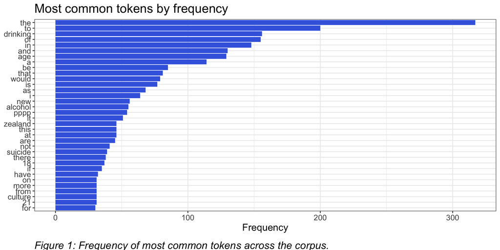

## Token frequency comparison

Fig. 2 plots the proportion of the total tokens that a particular token takes up in the single text compared to the corpus token proportions.

Tokens closer to the line have similar frequencies in both sets of texts.

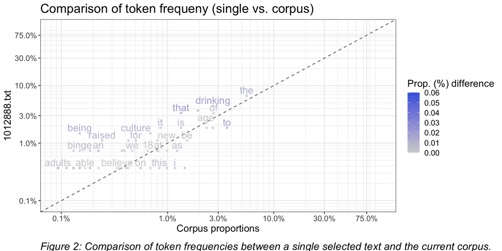

## Zipf’s Law

Zipf’s law states that the frequency of a word appearing is inversely proportional to its rank.

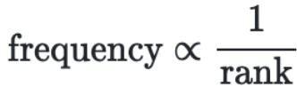

This inverse proportional relationship is visualised by plotting these values on log scales in Fig. 3.

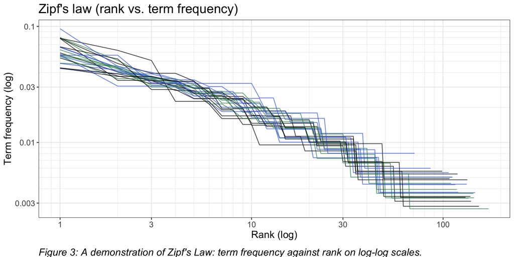

## Term frequency-inverse document frequency (tf-idf)

Term frequency-inverse document frequency (tf-idf) is a method used to quantify which words are important to a document.

Tf-idf is the product of a term’s frequency and the inverse document frequency, producing a statistic which measures how important a term is to a document.

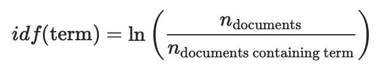

The method aims to decrease weighting of common terms and increase weighting of terms with low frequencies.

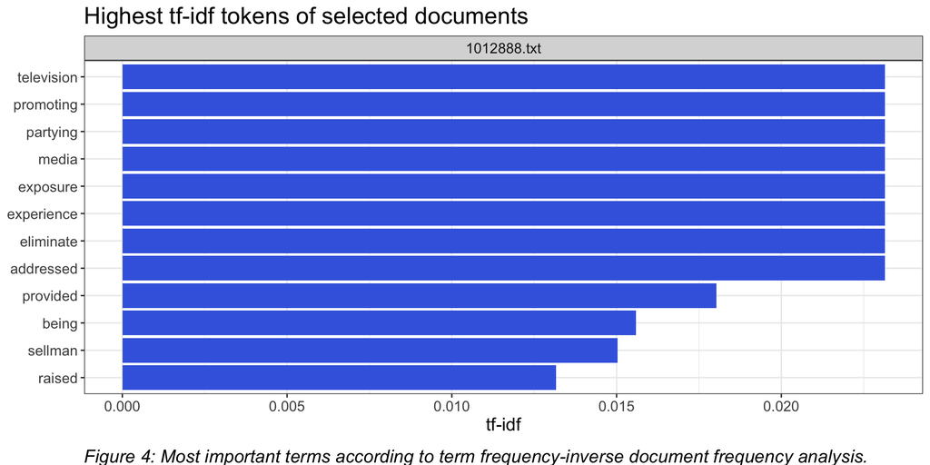

Tf-idf analysis shows some of the most important words to the document 1012888.txt are: addressed , eliminate , and experience .